# ML for Economists - PS2

Dimension Reduction

Ariel Karlinsky

06/04/2019

This *R Markdown* document contains both code and text problem set 2 in HUJI course 57750.

# Part 1

We begin by importing the *glmnet* and *ISLR* libraries. We additionally include some useful libraries *TidyVerse* for data manipulation and plotting, and the *broom* package for tidying up the *glmnet* output (as shown [here](http://varianceexplained.org/broom-gallery/snippets/broom-glmnet.html)) and load the *Credit* Dataset into *Dat* tibble.

```r
library(glmnet)
library(ISLR)
library(tidyverse)
library(broom)

Dat <- as_tibble(Credit)
```

## Q2

The help tab for the *Credit* dataset describes it as “A simulated data set containing information on ten thousand customers. The aim here is to predict which customers will default on their credit card debt.” However, this description is false. It has 400 observations and 12 variables. Running summary() of the data yields:

```r
summary(Dat)
```

```
##        ID            Income           Limit           Rating
##  Min.   :  1.0   Min.   : 10.35   Min.   :  855   Min.   : 93.0
##  1st Qu.:100.8   1st Qu.: 21.01   1st Qu.: 3088   1st Qu.:247.2
##  Median :200.5   Median : 33.12   Median : 4622   Median :344.0
##  Mean   :200.5   Mean   : 45.22   Mean   : 4736   Mean   :354.9
##  3rd Qu.:300.2   3rd Qu.: 57.47   3rd Qu.: 5873   3rd Qu.:437.2
##  Max.   :400.0   Max.   :186.63   Max.   :13913   Max.   :982.0
##      Cards            Age          Education        Gender    Student
##  Min.   :1.000   Min.   :23.00   Min.   : 5.00    Male :193   No :360
##  1st Qu.:2.000   1st Qu.:41.75   1st Qu.:11.00   Female:207   Yes: 40
##  Median :3.000   Median :56.00   Median :14.00
##  Mean   :2.958   Mean   :55.67   Mean   :13.45
##  3rd Qu.:4.000   3rd Qu.:70.00   3rd Qu.:16.00
##  Max.   :9.000   Max.   :98.00   Max.   :20.00
##  Married              Ethnicity      Balance
##  No :155   African American: 99   Min.   :   0.00
##  Yes:245   Asian           :102   1st Qu.:  68.75
##            Caucasian       :199   Median : 459.50
##                                   Mean   : 520.01
##                                   3rd Qu.: 863.00
##                                   Max.   :1999.00
```

## Q3

As we will only use quantitative variables, we create a new trimmed down version of the dataset without the following variables: ID, Gender, Student, Married, Ethnicity and store it as *Dat2*. We then load this trimmed down version for *glmnet* with *model.matrix()* (we remove the intercept using *-1* in the *model.matrix()* formula:

```r
Dat2 <- Dat %>%
  select(-c(ID,Gender,Student,Married,Ethnicity))
model_matrix <- model.matrix(object = Income ~. - 1, data = Dat2)
```

## Q4

All the models we estimate have the following form, they minimize the following problem, as seen [here](https://web.stanford.edu/~hastie/glmnet/glmnet_alpha.html) and in the “Dimensionality Reduction slides”

$$\min_{\beta} \frac{1}{N} \sum_{i=1}^{N}(y_i-\beta^T x_i) + \lambda\left[(1-\alpha)||\beta||_2^2/2 + \alpha ||\beta||_1\right]
\$$

```r
fit_lasso <- glmnet(y=Dat2$Income, x=model_matrix, alpha = 1)
fit_ridge <- glmnet(y=Dat2$Income, x=model_matrix, alpha = 0)
fit_elasticnet1 <- glmnet(y=Dat2$Income, x=model_matrix, alpha = 0.05)
fit_elasticnet2 <- glmnet(y=Dat2$Income, x=model_matrix, alpha = 0.95)
```

## Q5

We use *coeff()* on the fitted models to see them. We use the t() function to transpose them as there are many more columns (values of lambda, from high to low) than rows (variables). We will see this more clearly plotted in Q7.

```r
"Lasso"
```

```
## [1] "Lasso"
```

```r
t((coef(fit_lasso)))
```

```
## 68 x 7 sparse Matrix of class "dgCMatrix"
##     (Intercept)       Limit       Rating       Cards         Age
## s0   45.2188850 .           .            .           .
## s1   40.1307451 0.001074445 .            .           .
## s2   35.4946214 0.002053439 .            .           .
## s3   31.2703583 0.002945461 .            .           .
## s4   27.4167357 0.003758239 1.304817e-05 .           .
## s5   23.8935376 0.004491620 1.544817e-04 .           .
## s6   20.6445598 0.005088439 1.345341e-03 .           .
## s7   17.5573786 0.005398627 5.904571e-03 .           .
## s8   14.7438282 0.005680106 1.007591e-02 .           .
## s9   12.1778804 0.005932260 1.394093e-02 .           .
## s10   9.8437574 0.006169146 1.735650e-02 .           .
## s11   7.7131548 0.006377922 2.057374e-02 .           .
## s12   5.7743093 0.006572719 2.343722e-02 .           .
## s13   4.0078594 0.006750494 2.604211e-02 .           .
## s14   2.3964599 0.006909020 2.846698e-02 .           .
## s15   0.9296079 0.007056033 3.063821e-02 .           .
## s16  -0.4077599 0.007188463 3.263920e-02 .           .
## s17  -1.6266390 0.007308540 3.447118e-02 .           .
## s18  -2.7345420 0.007422912 3.606661e-02 .           .
## s19  -3.7462008 0.007523111 3.757999e-02 .           .
## s20  -4.6671204 0.007616004 3.893520e-02 .           .
## s21  -6.7561055 0.007775665 4.752802e-02 .           .
## s22  -9.6376852 0.007992082 6.097817e-02 .           .
## s23 -12.2664510 0.008183353 7.332124e-02 .           .
## s24 -14.6599846 0.008360799 8.452082e-02 .           .
## s25 -16.8391192 0.008525767 9.467672e-02 .           .
## s26 -18.9580891 0.008627467 1.045610e-01 .           0.002260534
## s27 -20.8989891 0.008817029 1.120467e-01 .           0.005743305
## s28 -22.6925546 0.008944949 1.195423e-01 .           0.008897102
## s29 -24.3262768 0.009062470 1.263578e-01 .           0.011770953
## s30 -25.8137040 0.009171757 1.325350e-01 .           0.014390017
## s31 -27.1698223 0.009269756 1.381869e-01 .           0.016776039
## s32 -28.4077584 0.009354692 1.434013e-01 .           0.018949069
## s33 -29.5317455 0.009439639 1.480404e-01 .           0.020930831
## s34 -30.5595711 0.009510022 1.523715e-01 .           0.022734888
## s35 -31.4933143 0.009579424 1.562396e-01 .           0.024379923
## s36 -32.3461932 0.009638691 1.598229e-01 .           0.025877887
## s37 -33.1218994 0.009695359 1.630484e-01 .           0.027243424
```

[output cut: 84 more lines]

```
## s53 0.005991261 -0.062736552
## s54 0.012620162 -0.063018962
## s55 0.018658717 -0.063276041
## s56 0.024155558 -0.063509301
## s57 0.029194537 -0.063726609
## s58 0.033725774 -0.063912086
## s59 0.037897202 -0.064092214
## s60 0.041716267 -0.064257900
## s61 0.045059758 -0.064376822
## s62 0.048328787 -0.064542332
## s63 0.051128124 -0.064644155
## s64 0.053728044 -0.064753175
## s65 0.056210267 -0.064870493
## s66 0.058499398 -0.064961254
## s67 0.060548189 -0.065036137
```

```r
"Ridge"
```

```
## [1] "Ridge"
```

```r
t((coef(fit_ridge)))
```

```
## 100 x 7 sparse Matrix of class "dgCMatrix"
##     (Intercept)        Limit       Rating         Cards          Age
## s0   45.2188850 1.221670e-38 1.820870e-37 -4.743833e-37 3.618647e-37
## s1   45.0061639 1.669953e-05 2.489016e-04 -6.546917e-04 4.950599e-04
## s2   44.9855079 1.832149e-05 2.730764e-04 -7.189451e-04 5.431871e-04
## s3   44.9628551 2.010033e-05 2.995893e-04 -7.895488e-04 5.959781e-04
## s4   44.9380143 2.205108e-05 3.286644e-04 -8.671390e-04 6.538817e-04
## s5   44.9107763 2.419019e-05 3.605471e-04 -9.524178e-04 7.173894e-04
## s6   44.8809124 2.653566e-05 3.955053e-04 -1.046160e-03 7.870391e-04
## s7   44.8481726 2.910717e-05 4.338325e-04 -1.149220e-03 8.634197e-04
## s8   44.8122838 3.192620e-05 4.758489e-04 -1.262542e-03 9.471751e-04
## s9   44.7729477 3.501626e-05 5.219048e-04 -1.387170e-03 1.039010e-03
## s10  44.7298385 3.840299e-05 5.723823e-04 -1.524258e-03 1.139694e-03
## s11  44.6826010 4.211440e-05 6.276989e-04 -1.675082e-03 1.250069e-03
## s12  44.6308477 4.618101e-05 6.883096e-04 -1.841055e-03 1.371055e-03
## s13  44.5741565 5.063614e-05 7.547107e-04 -2.023743e-03 1.503656e-03
## s14  44.5120672 5.551610e-05 8.274429e-04 -2.224879e-03 1.648968e-03
## s15  44.4440799 6.086031e-05 9.070947e-04 -2.446389e-03 1.808186e-03
## s16  44.3696506 6.671178e-05 9.943065e-04 -2.690409e-03 1.982614e-03
## s17  44.2881883 7.311720e-05 1.089774e-03 -2.959313e-03 2.173671e-03
## s18  44.1990519 8.012729e-05 1.194254e-03 -3.255741e-03 2.382903e-03
## s19  44.1015465 8.779706e-05 1.308565e-03 -3.582628e-03 2.611993e-03
## s20  43.9949197 9.618613e-05 1.433597e-03 -3.943246e-03 2.862767e-03
## s21  43.8783584 1.053590e-04 1.570309e-03 -4.341241e-03 3.137211e-03
## s22  43.7509846 1.153854e-04 1.719741e-03 -4.780679e-03 3.437478e-03
## s23  43.6118524 1.263405e-04 1.883014e-03 -5.266103e-03 3.765901e-03
## s24  43.4599442 1.383053e-04 2.061335e-03 -5.802585e-03 4.125003e-03
## s25  43.2941677 1.513670e-04 2.256002e-03 -6.395798e-03 4.517513e-03
## s26  43.1133529 1.656189e-04 2.468407e-03 -7.052092e-03 4.946375e-03
## s27  42.9162500 1.811613e-04 2.700042e-03 -7.778573e-03 5.414758e-03
## s28  42.7015271 1.981009e-04 2.952498e-03 -8.583202e-03 5.926071e-03
## s29  42.4677696 2.165515e-04 3.227471e-03 -9.474902e-03 6.483972e-03
## s30  42.2134802 2.366340e-04 3.526761e-03 -1.046367e-02 7.092377e-03
## s31  41.9370797 2.584762e-04 3.852272e-03 -1.156073e-02 7.755467e-03
## s32  41.6369097 2.822128e-04 4.206013e-03 -1.277863e-02 8.477697e-03
## s33  41.3112370 3.079855e-04 4.590091e-03 -1.413146e-02 9.263795e-03
## s34  40.9582600 3.359420e-04 5.006709e-03 -1.563500e-02 1.011876e-02
## s35  40.5761169 3.662362e-04 5.458157e-03 -1.730689e-02 1.104788e-02
## s36  40.1628971 3.990270e-04 5.946802e-03 -1.916687e-02 1.205668e-02
## s37  39.7166549 4.344776e-04 6.475075e-03 -2.123695e-02 1.315096e-02
```

[output cut: 148 more lines]

```
## s85 -7.292675e-02 -1.512800e-02
## s86 -6.947694e-02 -1.682040e-02
## s87 -6.569482e-02 -1.856375e-02
## s88 -6.163052e-02 -2.034161e-02
## s89 -5.729082e-02 -2.215484e-02
## s90 -5.273150e-02 -2.398581e-02
## s91 -4.797537e-02 -2.583058e-02
## s92 -4.304948e-02 -2.768435e-02
## s93 -3.801016e-02 -2.952996e-02
## s94 -3.287619e-02 -3.136719e-02
## s95 -2.770083e-02 -3.317953e-02
## s96 -2.250375e-02 -3.496727e-02
## s97 -1.733176e-02 -3.671535e-02
## s98 -1.220403e-02 -3.842473e-02
## s99 -7.154885e-03 -4.008594e-02
```

```r
"Elastic net with alpha = 0.05"
```

```
## [1] "Elastic net with alpha = 0.05"
```

```r
t((coef(fit_elasticnet1)))
```

```
## 99 x 7 sparse Matrix of class "dgCMatrix"
##     (Intercept)        Limit      Rating        Cards          Age
## s0   45.2188850 .            .            .           .
## s1   44.5365321 6.844451e-05 0.001009261  .           .
## s2   43.8015343 1.417604e-04 0.002101849  .           .
## s3   43.0153131 2.201869e-04 0.003270566  .           .
## s4   42.1760864 3.039022e-04 0.004518058  .           .
## s5   41.2823129 3.930602e-04 0.005846611  .           .
## s6   40.3327464 4.877858e-04 0.007258072  .           .
## s7   39.3264927 5.881685e-04 0.008753766  .           .
## s8   38.2344972 6.926307e-04 0.010310188  .           .
## s9   37.0436531 7.997803e-04 0.011906153  .           .
## s10  35.8035459 9.119638e-04 0.013577077  .           .
## s11  34.5163312 1.029108e-03 0.015321741  .           .
## s12  33.1846894 1.151100e-03 0.017138438  .           .
## s13  31.8117694 1.277796e-03 0.019025008  .           .
## s14  30.4011497 1.409026e-03 0.020978883  .           .
## s15  28.9567850 1.544595e-03 0.022997156  .           .
## s16  27.4829392 1.684292e-03 0.025076661  .           .
## s17  25.9841070 1.827895e-03 0.027214064  .           .
## s18  24.4499612 1.975178e-03 0.029405966  .           0.0002688465
## s19  22.5683852 2.124708e-03 0.031630413  .           0.0066921437
## s20  20.6692918 2.277404e-03 0.033899862  .           0.0132503463
## s21  18.7591948 2.432902e-03 0.036211796  .           0.0199160315
## s22  16.8441055 2.591065e-03 0.038562850  .           0.0266581233
## s23  14.9298974 2.751739e-03 0.040950660  .           0.0334425906
## s24  13.0221966 2.914801e-03 0.043373355  .           0.0402326766
## s25  11.1263061 3.080172e-03 0.045829587  .           0.0469892606
## s26   9.2471420 3.247813e-03 0.048318536  .           0.0536713059
## s27   7.3901841 3.417566e-03 0.050838178  .           0.0602380281
## s28   5.5579510 3.589729e-03 0.053390939  .           0.0666439355
## s29   3.7618857 3.732931e-03 0.055505531  .           0.0732599297
## s30   2.0160177 3.871656e-03 0.057553385  .           0.0797638776
## s31   0.3253638 4.005734e-03 0.059528909  .           0.0861324425
## s32  -1.3050940 4.134386e-03 0.061431380  .           0.0923469958
## s33  -2.8219874 4.257787e-03 0.063258858 -0.018369402 0.0984223055
## s34  -4.1542541 4.375623e-03 0.065017282 -0.080028134 0.1043946382
## s35  -5.5390837 4.547286e-03 0.067591907 -0.128152155 0.1091363080
## s36  -6.9271157 4.739996e-03 0.070489317 -0.169234252 0.1131155851
## s37  -8.2916644 4.936972e-03 0.073439448 -0.206674313 0.1166004151
```

[output cut: 146 more lines]

```
## s84 0.064388797 -6.299471e-02
## s85 0.065644612 -6.324963e-02
## s86 0.066823715 -6.348822e-02
## s87 0.067916235 -6.370705e-02
## s88 0.068927623 -6.390734e-02
## s89 0.069864168 -6.409057e-02
## s90 0.070701792 -6.425372e-02
## s91 0.071522310 -6.441138e-02
## s92 0.072243105 -6.454800e-02
## s93 0.072923611 -6.467619e-02
## s94 0.073527241 -6.478930e-02
## s95 0.074131100 -6.490070e-02
## s96 0.074654098 -6.499539e-02
## s97 0.075178041 -6.508819e-02
## s98 0.075631379 -6.516698e-02
```

```r
"Elastic net with alpha = 0.95"
```

```
## [1] "Elastic net with alpha = 0.95"
```

```r
t((coef(fit_elasticnet2)))
```

```
## 69 x 7 sparse Matrix of class "dgCMatrix"
##      (Intercept)        Limit      Rating       Cards          Age
## s0   45.21888500 .            .           .           .
## s1   40.04064218 0.0007074496 0.005150292 .           .
## s2   35.20835238 0.0012099264 0.012060645 .           .
## s3   30.79079117 0.0016662282 0.018418616 .           .
## s4   26.75659450 0.0020887346 0.024147402 .           .
## s5   23.07441427 0.0024817814 0.029277475 .           .
## s6   19.71157218 0.0028402180 0.033969619 .           .
## s7   16.64392168 0.0031738900 0.038160506 .           .
## s8   13.84344792 0.0034780061 0.041992988 .           .
## s9   11.29026513 0.0037617765 0.045400211 .           .
## s10   8.96433935 0.0040292652 0.048384396 .           .
## s11   6.84289246 0.0042746326 0.051087627 .           .
## s12   4.90894126 0.0045012541 0.053512720 .           .
## s13   3.14860721 0.0047156514 0.055611763 .           .
## s14   1.54614956 0.0049173046 0.057436039 .           .
## s15   0.08544054 0.0051023195 0.059082944 .           .
## s16  -1.24085042 0.0052823784 0.060417266 .           .
## s17  -2.44968032 0.0054472187 0.061623701 .           .
## s18  -3.54616667 0.0056085162 0.062560891 .           .
## s19  -4.54503757 0.0057567595 0.063397229 .           .
## s20  -5.44976050 0.0059031661 0.063992822 .           .
## s21  -7.24525883 0.0062114913 0.068966174 .           .
## s22  -9.93357631 0.0066866650 0.078240069 .           .
## s23 -12.40165433 0.0071100164 0.086910945 .           .
## s24 -14.66438791 0.0074914680 0.094942541 .           .
## s25 -16.78464115 0.0078126326 0.102681972 .           0.0007205452
## s26 -18.85471668 0.0081368298 0.109164565 .           0.0045640849
## s27 -20.75843620 0.0084100876 0.115445377 .           0.0080222191
## s28 -22.50208030 0.0086498197 0.121338705 .           0.0111428990
## s29 -24.09856663 0.0088602879 0.126854857 .           0.0139606307
## s30 -25.55771852 0.0090494419 0.131944276 .           0.0165065999
## s31 -26.89423236 0.0092132074 0.136728578 .           0.0188077221
## s32 -28.11555734 0.0093598763 0.141142933 .           0.0208890856
## s33 -29.23428401 0.0094856095 0.145296253 .           0.0227719479
## s34 -30.25857353 0.0095935947 0.149189956 .           0.0244759913
## s35 -31.19372010 0.0096910009 0.152762760 .           0.0260195189
## s36 -32.05004803 0.0097736390 0.156117115 .           0.0274174786
## s37 -32.83140651 0.0098486283 0.159185356 .           0.0286848862
```

[output cut: 86 more lines]

```
## s54 0.011708480 -0.062891562
## s55 0.017830842 -0.063163560
## s56 0.023403551 -0.063408708
## s57 0.028478538 -0.063631393
## s58 0.033097866 -0.063833484
## s59 0.037335836 -0.064021789
## s60 0.041141709 -0.064182571
## s61 0.044687360 -0.064344914
## s62 0.047797897 -0.064466441
## s63 0.050775466 -0.064611288
## s64 0.053392254 -0.064717953
## s65 0.055905651 -0.064826065
## s66 0.058196803 -0.064917999
## s67 0.060315155 -0.065009860
## s68 0.062198801 -0.065082678
```

The elastic net models are a mix of the Lasso and Ridge penalties. The first model, with $\alpha = 0.05$ should be closer to the Ridge, and it indeed zeroes out less variables than the model with $\alpha = 0.95$ which is more similar to the Lasso.

## Q6

Instead of using *model$df*, which prints the number of non-zero coefficients for each value of lambda, we use *print(model)* to see more concisely how many non zero coefficients we have for each value of $\lambda$.

```r
print(fit_lasso)
```

```
##
## Call:  glmnet(x = model_matrix, y = Dat2$Income, alpha = 1)
##
##       Df   %Dev   Lambda
##  [1,]  0 0.0000 27.88000
##  [2,]  1 0.1065 25.40000
##  [3,]  1 0.1950 23.15000
##  [4,]  1 0.2684 21.09000
##  [5,]  2 0.3294 19.22000
##  [6,]  2 0.3801 17.51000
##  [7,]  2 0.4223 15.95000
##  [8,]  2 0.4572 14.54000
##  [9,]  2 0.4862 13.25000
## [10,]  2 0.5102 12.07000
## [11,]  2 0.5302 11.00000
```

[output cut: 57 more lines]

```r
print(fit_ridge)
```

```
##
## Call:  glmnet(x = model_matrix, y = Dat2$Income, alpha = 0)
##
##        Df      %Dev    Lambda
##   [1,]  6 3.031e-36 27880.000
##   [2,]  6 4.135e-03 25400.000
##   [3,]  6 4.535e-03 23150.000
##   [4,]  6 4.975e-03 21090.000
##   [5,]  6 5.456e-03 19220.000
##   [6,]  6 5.984e-03 17510.000
##   [7,]  6 6.562e-03 15950.000
##   [8,]  6 7.195e-03 14540.000
##   [9,]  6 7.889e-03 13250.000
##  [10,]  6 8.650e-03 12070.000
##  [11,]  6 9.482e-03 11000.000
```

[output cut: 89 more lines]

```r
print(fit_elasticnet1)
```

```
##
## Call:  glmnet(x = model_matrix, y = Dat2$Income, alpha = 0.05)
##
##        Df    %Dev    Lambda
##   [1,]  0 0.00000 557.60000
##   [2,]  2 0.01403 508.10000
##   [3,]  2 0.02897 463.00000
##   [4,]  2 0.04474 421.80000
##   [5,]  2 0.06135 384.40000
##   [6,]  2 0.07877 350.20000
##   [7,]  2 0.09697 319.10000
##   [8,]  2 0.11590 290.80000
##   [9,]  3 0.13620 264.90000
##  [10,]  3 0.15780 241.40000
##  [11,]  3 0.17970 219.90000
```

[output cut: 88 more lines]

```r
print(fit_elasticnet2)
```

```
##
## Call:  glmnet(x = model_matrix, y = Dat2$Income, alpha = 0.95)
##
##       Df   %Dev   Lambda
##  [1,]  0 0.0000 29.35000
##  [2,]  2 0.1044 26.74000
##  [3,]  2 0.1919 24.37000
##  [4,]  2 0.2648 22.20000
##  [5,]  2 0.3256 20.23000
##  [6,]  2 0.3763 18.43000
##  [7,]  2 0.4186 16.79000
##  [8,]  2 0.4537 15.30000
##  [9,]  2 0.4830 13.94000
## [10,]  2 0.5074 12.70000
## [11,]  2 0.5277 11.58000
```

[output cut: 58 more lines]

For the Lasso, lambda starts at 27.88 and decreases down to 0.054. The number of non-zero coefficients rises from 0 to 6 (maximum available) respectively.

For the Ridge, lambda starts at 27880 and decreases down to 2.78. The differences between the Ridge and Lasso lambdas are not important as the penalty itself is on a different scale(one is the L2 norm, the other L1). The number of non-zero coefficients stays 6 throughout, as we saw in the previous question that the Ridge never truly zeroes out coefficients.

For the elastic net with $\alpha = 0.05$, lambda starts at 557.6 and decreases to 0.06. The number of non-zero coefficients rises from 0 to 6 respectively.

For the elastic net with $\alpha = 0.95$, lambda starts at 29.35 and decreases to 0.05. The number of non-zero coefficients rises from 0 to 6 respectively.

## Q7

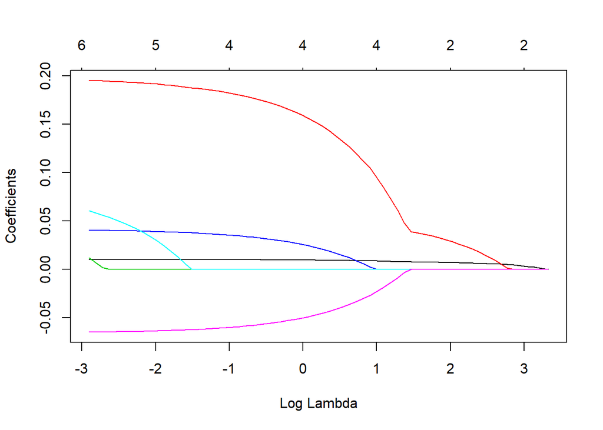

```r
plot(fit_lasso, xvar="lambda")
```

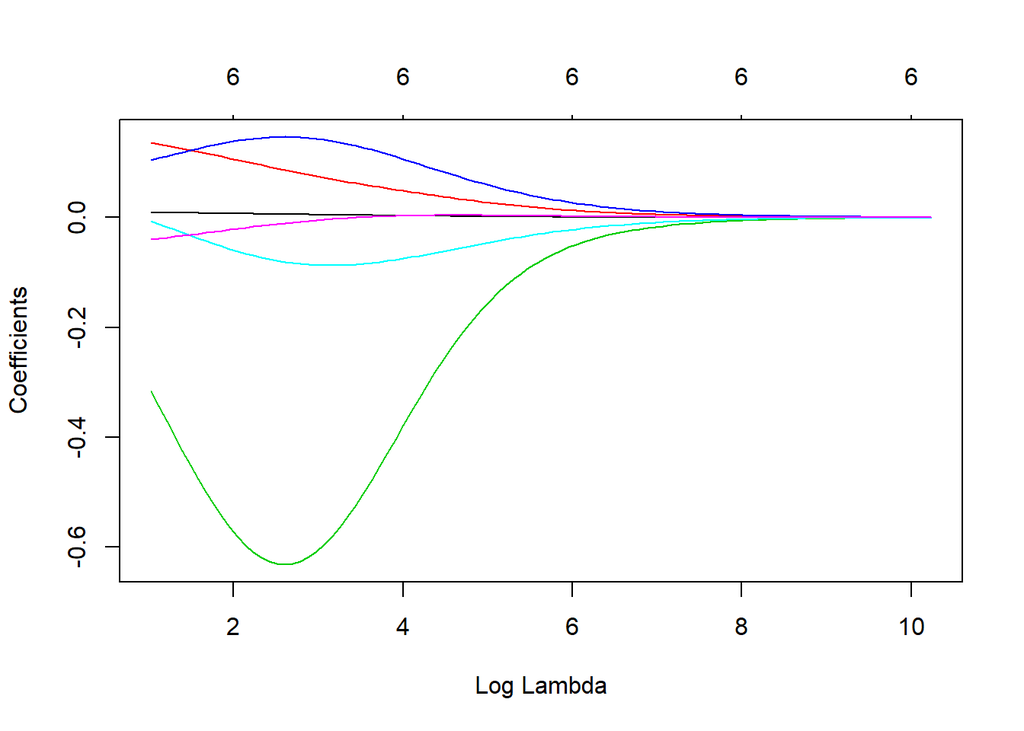

```r
plot(fit_ridge, xvar="lambda")
```

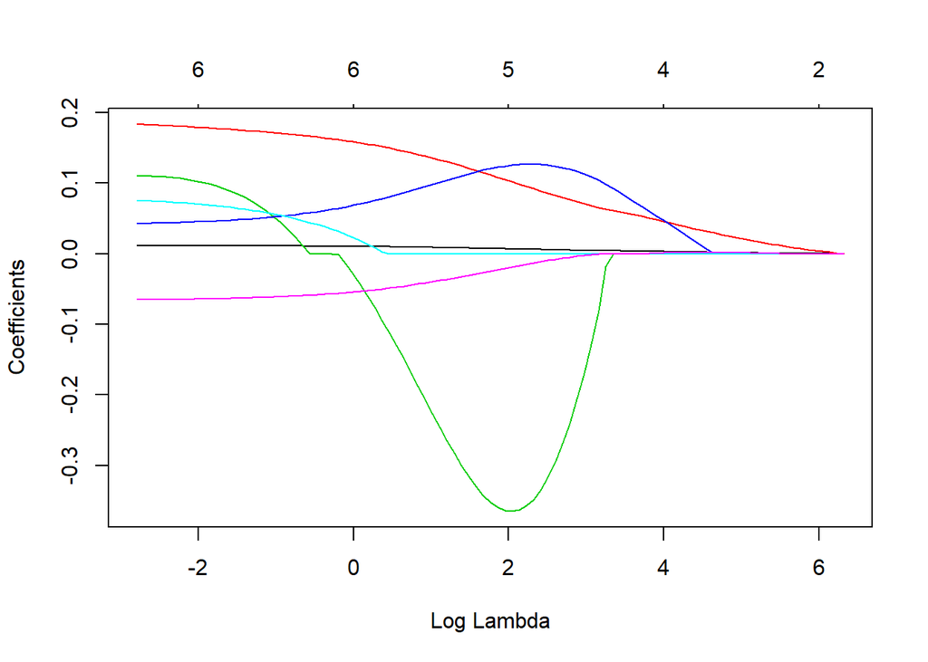

```r
plot(fit_elasticnet1, xvar="lambda")
```

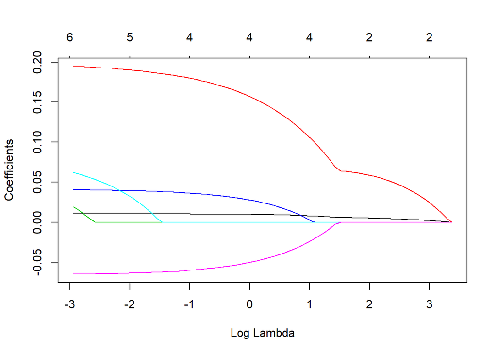

```r
plot(fit_elasticnet2, xvar="lambda")
```

Unfortunately, this plot function doesn’t show the variables names. Still, we can see more clearly what we saw in previous questions. For the Lasso, as $\lambda$ increases - the coefficients move to zero and eventually get zeroed out. We see that the coefficients paths themselves are non-linear. For the Ridge, as $\lambda$ increases - the coefficients move non-linearly closer and closer to zero yet never reach it exactly (notice the higher x-axis always displays 6 non-zeroed coefficients). For the Elastic net models, The one with $\alpha = 0.05$ seems closer to the coefficient path of the Ridge, and the one with $\alpha=0.95$ is more similar to the Lasso - as expected and as we saw in the previous questions.

# Part 2

## Q1

We split *Credit* into 4 sets of data: training-predictors, training-test, test-predictors and test-response.

```r
credit_train <- Dat2 %>% sample_frac(0.9)
# credit_train_x <- credit_train %>% select(-Income)
# credit_train_y <- credit_train %>% select(Income)
credit_test <- Dat2 %>% setdiff(credit_train)
# credit_test_x <- credit_test %>% select(-Income)
# credit_test_y <- credit_test %>% select(Income)

model_matrix_train <- model.matrix(object = Income ~. - 1, data = credit_train)
model_matrix_test <- model.matrix(object = Income ~. - 1, data = credit_test)
```

## Q2

We estimate CV Ridge and Lasso models on the training set and response with 5-fold CV:

```r
fit_lasso_cv <- cv.glmnet(y=credit_train$Income, x=model_matrix_train, alpha = 1, nfolds = 5)
fit_ridge_cv <- cv.glmnet(y=credit_train$Income, x=model_matrix_train, alpha = 0, nfolds = 5)
```

## Q3

We find for each model the $\lambda$ that minimizes the CV MSE:

```r
fit_lasso_cv$lambda.min
```

```
## [1] 0.2191445
```

```r
fit_ridge_cv$lambda.min
```

```
## [1] 3.034902
```

For the Lasso model, the $\lambda$ that minimizes the CV MSE is 0.2191445. For the Ridge model, the $\lambda$ that minimizes the CV MSE is 3.0349021.

## Q4

We plot the CV error as a function of $\ln\lambda$:

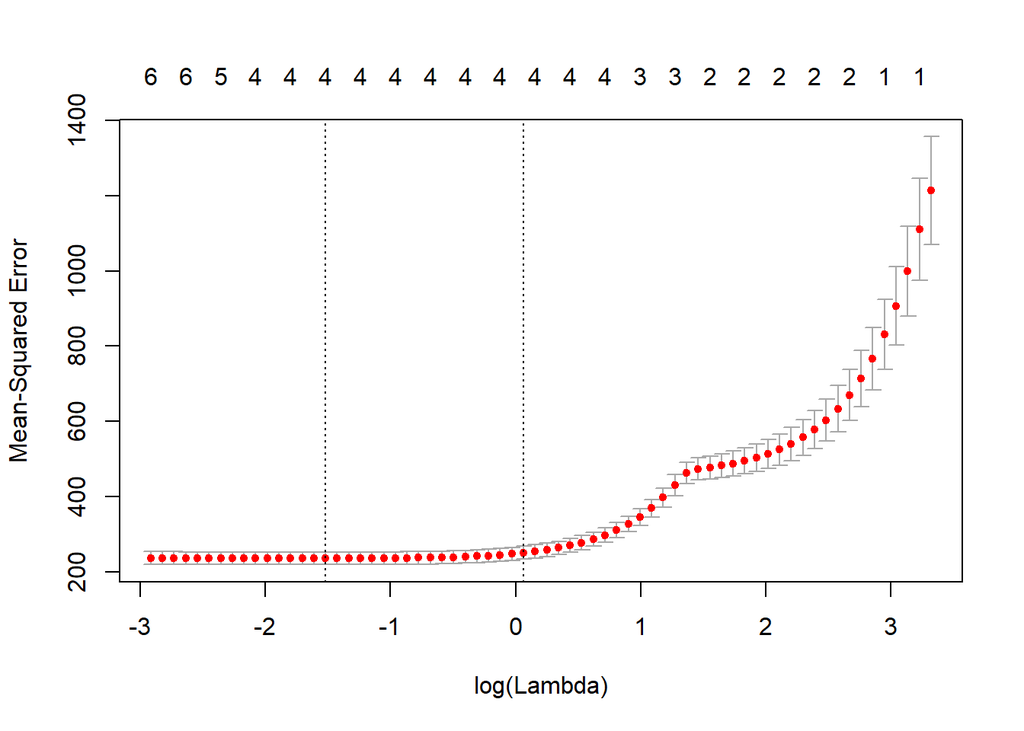

```r
plot(fit_lasso_cv)
```

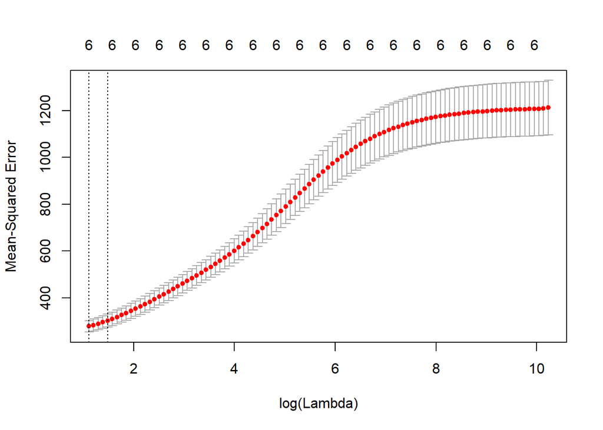

```r
plot(fit_ridge_cv)
```

We see that for the Lasso, the min CV error is somewhere in the middle of the $\lambda$ path, whereas for the Ridge, It is at the very beginning.

## Q5

We predict Income using the Test set predictors at the optimal lambdas found in Q3.

```r
lasso_cv_yhat <- predict(fit_lasso_cv, newx=model_matrix_test, s=fit_lasso_cv$lambda.min)
ridge_cv_yhat <-predict(fit_ridge_cv, newx=model_matrix_test, s=fit_ridge_cv$lambda.min)
```

## Q6

```r
lasso_mse <- mean((lasso_cv_yhat - credit_test %>% pull(Income))^2)
ridge_mse <- mean((ridge_cv_yhat - credit_test %>% pull(Income))^2)
```

# Part 3

> In this exercise we will predict wine quality using different chemical aspects of the wine using the Wine data set.

## Q1

We begin by loading the *readxl* library and importing the *winequality.xlsx* data into *wine*. We additionally load the *pls* library in order to conduct PCA regression:

```r
library(readxl)
library(pls)
wine <- read_excel("winequality.xlsx")
```

We use glimpse() and summary() to see variable classes, NAs etc.:

```r
glimpse(wine)
```

```
## Observations: 6,497
## Variables: 13
## $ `fixed acidity`        <dbl> 7.4, 7.8, 7.8, 11.2, 7.4, 7.4, 7.9, 7.3...
## $ `volatile acidity`     <dbl> 0.700, 0.880, 0.760, 0.280, 0.700, 0.66...
## $ `citric acid`          <dbl> 0.00, 0.00, 0.04, 0.56, 0.00, 0.00, 0.0...
## $ `residual sugar`       <dbl> 1.9, 2.6, 2.3, 1.9, 1.9, 1.8, 1.6, 1.2,...
## $ chlorides              <dbl> 0.076, 0.098, 0.092, 0.075, 0.076, 0.07...
## $ `free sulfur dioxide`  <dbl> 11, 25, 15, 17, 11, 13, 15, 15, 9, 17, ...
## $ `total sulfur dioxide` <dbl> 34, 67, 54, 60, 34, 40, 59, 21, 18, 102...
## $ density                <dbl> 0.9978, 0.9968, 0.9970, 0.9980, 0.9978,...
## $ pH                     <dbl> 3.51, 3.20, 3.26, 3.16, 3.51, 3.51, 3.3...
## $ sulphates              <dbl> 0.56, 0.68, 0.65, 0.58, 0.56, 0.56, 0.4...
## $ alcohol                <dbl> 9.4, 9.8, 9.8, 9.8, 9.4, 9.4, 9.4, 10.0...
## $ color                  <chr> "red", "red", "red", "red", "red", "red...
## $ quality                <dbl> 5, 5, 5, 6, 5, 5, 5, 7, 7, 5, 5, 5, 5, ...
```

```r
summary(wine)
```

```
##  fixed acidity    volatile acidity  citric acid     residual sugar
##  Min.   : 3.800   Min.   :0.0800   Min.   :0.0000   Min.   : 0.600
##  1st Qu.: 6.400   1st Qu.:0.2300   1st Qu.:0.2500   1st Qu.: 1.800
##  Median : 7.000   Median :0.2900   Median :0.3100   Median : 3.000
##  Mean   : 7.215   Mean   :0.3397   Mean   :0.3186   Mean   : 5.443
##  3rd Qu.: 7.700   3rd Qu.:0.4000   3rd Qu.:0.3900   3rd Qu.: 8.100
##  Max.   :15.900   Max.   :1.5800   Max.   :1.6600   Max.   :65.800
##    chlorides       free sulfur dioxide total sulfur dioxide
##  Min.   :0.00900   Min.   :  1.00      Min.   :  6.0
##  1st Qu.:0.03800   1st Qu.: 17.00      1st Qu.: 77.0
##  Median :0.04700   Median : 29.00      Median :118.0
##  Mean   :0.05603   Mean   : 30.53      Mean   :115.7
##  3rd Qu.:0.06500   3rd Qu.: 41.00      3rd Qu.:156.0
##  Max.   :0.61100   Max.   :289.00      Max.   :440.0
##     density             pH          sulphates         alcohol
##  Min.   :0.9871   Min.   :2.720   Min.   :0.2200   Min.   : 8.00
##  1st Qu.:0.9923   1st Qu.:3.110   1st Qu.:0.4300   1st Qu.: 9.50
##  Median :0.9949   Median :3.210   Median :0.5100   Median :10.30
##  Mean   :0.9947   Mean   :3.219   Mean   :0.5313   Mean   :10.49
##  3rd Qu.:0.9970   3rd Qu.:3.320   3rd Qu.:0.6000   3rd Qu.:11.30
##  Max.   :1.0390   Max.   :4.010   Max.   :2.0000   Max.   :14.90
##     color              quality
##  Length:6497        Min.   :3.000
##  Class :character   1st Qu.:5.000
##  Mode  :character   Median :6.000
##                     Mean   :5.818
##                     3rd Qu.:6.000
##                     Max.   :9.000
```

This dataset has 13 variables and 6497 observations. We see that all variables are numeric (doubles), except for color which is a string variable. Also, we have no missing values (NAs). It should be noted that the *quality* variable is not continuous but discrete. Yet since it has an ordinal nature we will treat it as if it’s continuous. The data seems ready for modelling.

## Q2

We now estimate PCR model. A full model would be *quality* as predicted by all other variables except for *color* - Thus the X dimension is 11. Since PCR is a Dimensionality reduction model, I choose the number of components at half (more precisely, floor of half) - it is thus set at 5.

```r
fit_pcr <- pcr(data=wine, formula=quality ~ . - color, scale=TRUE, ncomp= floor(0.5*11),validation = "none")
```

## Q3

The output of the PCR model is given by:

```r
summary(fit_pcr)
```

```
## Data:    X dimension: 6497 11
##  Y dimension: 6497 1
## Fit method: svdpc
## Number of components considered: 5
## TRAINING: % variance explained
##          1 comps  2 comps  3 comps  4 comps  5 comps
## X        27.5443    50.22    64.36    73.19    79.73
## quality   0.5798    10.50    15.14    17.86    21.02
```

## Q4

We now view the coefficients and scores of the model

```r
fit_pcr$coefficients
```

```
## , , 1 comps
##
##                             quality
## `fixed acidity`        -0.009122489
## `volatile acidity`     -0.014545529
## `citric acid`           0.005821475
## `residual sugar`        0.013214679
## chlorides              -0.011082752
## `free sulfur dioxide`   0.016461585
## `total sulfur dioxide`  0.018620128
## density                -0.001716649
## pH                     -0.008354162
## sulphates              -0.011236421
## alcohol                -0.004066063
##
## , , 2 comps
##
##                             quality
## `fixed acidity`        -0.067704002
## `volatile acidity`     -0.035018689
## `citric acid`          -0.026103042
## `residual sugar`       -0.044245143
## chlorides              -0.065989965
## `free sulfur dioxide`   0.003933374
## `total sulfur dioxide`  0.003421312
## density                -0.103436077
## pH                      0.018792913
## sulphates              -0.044626783
## alcohol                 0.076931159
##
## , , 3 comps
##
##                             quality
## `fixed acidity`        -0.002202428
## `volatile acidity`     -0.081359732
## `citric acid`           0.062967017
## `residual sugar`       -0.069083547
## chlorides              -0.068505517
## `free sulfur dioxide`  -0.016310359
## `total sulfur dioxide` -0.012786214
```

[output cut: 19 more lines]

```
##
## , , 5 comps
##
##                              quality
## `fixed acidity`         0.0007602209
## `volatile acidity`     -0.1401769005
## `citric acid`           0.1300267296
## `residual sugar`       -0.0289014292
## chlorides              -0.1451512637
## `free sulfur dioxide`  -0.0049870674
## `total sulfur dioxide` -0.0112556912
## density                -0.0844570440
## pH                      0.0936762989
## sulphates               0.0845580546
## alcohol                 0.1664857744
```

```r
options(max.print=100)
fit_pcr$scores
```

```
##             Comp 1        Comp 2        Comp 3        Comp 4        Comp 5
## 1    -3.2057494326  4.164913e-01  2.7220270866  0.7967162204 -0.2028618845
## 2    -3.0388169236  1.107377e+00  2.0467948154  0.7701656436  1.3225535926
## 3    -3.0716570558  8.788968e-01  1.7424454942  0.8021955295  0.7620530557
## 4    -1.5711412092  2.112382e+00 -2.5927174662  0.2927619804 -0.6046542368
## 5    -3.2057494326  4.164913e-01  2.7220270866  0.7967162204 -0.2028618845
## 6    -3.0119338406  3.893675e-01  2.6699698056  0.6861020472 -0.2077957134
## 7    -2.1505386022  3.235813e-01  1.5585206797  1.4253020346  0.4310128519
## 8    -2.7109734530 -6.533606e-01  2.0220756987  1.3045087485  0.2886928411
## 9    -2.9450374015  3.314857e-01  1.7293467528  1.0901746291 -0.0099525185
## 10   -1.6602148082  1.164680e+00  0.3630258976 -1.0116941401 -0.8602152950
## 11   -2.1334484526  4.013478e-01  1.7937818417  0.7132505891  1.0864771822
## 12   -1.6602148082  1.164680e+00  0.3630258976 -1.0116941401 -0.8602152950
## 13   -2.4784141521 -9.521881e-01  3.1501702651  0.0265144735  0.4248443468
## 14   -4.7991815424  2.696915e+00  0.0881747014 -3.6564493725 -0.1161422908
## 15   -1.9962595768  3.330112e+00  0.9220386618 -1.7479736177  2.4430733392
## 16   -2.0396564468  3.350970e+00  0.8849288809 -1.9526672486  2.2414440788
## 17   -0.9864730325  1.293380e+00 -1.3669378735 -1.8747570523 -0.1941519300
## 18   -5.6939943608  4.678930e+00 -0.2082426613 -4.1166963560  5.1347531406
## 19   -2.5959083776  8.010020e-01  1.9598392151  1.2658121327  0.0490374453
## 20   -4.1078177717  4.382473e+00 -1.6020424866 -3.6457858964  4.6090640876
##  [ reached getOption("max.print") -- omitted 6477 rows ]
## attr(,"class")
## [1] "scores"
```

We see that, as we saw in summary(), the first and second PCs are usually the largest. I’m not sure what else there is to say about this.

# Part 4

In this section we also estimate a PCR, but this time with train and test sets and with cross-validation.

## Q1

The train test will comprise of 90% of observations, and the test of remaining 10%.

```r
wine_train <- wine %>% sample_frac(0.9)
wine_y_test <- wine %>% setdiff(wine_train) %>% pull(quality)
wine_x_test <- wine %>% setdiff(wine_train) %>% select(-quality)
```

## Q2

We estimate PCR with cross-validation:

```r
fit_pcr_cv <- pcr(data=wine_train, formula=quality ~ . - color, scale=TRUE, validation = "CV")
```

## Q3

The output of the cross-validated PCR model is given by:

```r
summary(fit_pcr_cv)
```

```
## Data:    X dimension: 5847 11
##  Y dimension: 5847 1
## Fit method: svdpc
## Number of components considered: 11
##
## VALIDATION: RMSEP
## Cross-validated using 10 random segments.
##        (Intercept)  1 comps  2 comps  3 comps  4 comps  5 comps  6 comps
## CV          0.8711   0.8687   0.8232   0.8026   0.7896   0.7734   0.7633
## adjCV       0.8711   0.8687   0.8232   0.8026   0.7895   0.7733   0.7632
##        7 comps  8 comps  9 comps  10 comps  11 comps
## CV      0.7593    0.752   0.7349    0.7349    0.7347
## adjCV   0.7591    0.752   0.7348    0.7348    0.7346
##
## TRAINING: % variance explained
##          1 comps  2 comps  3 comps  4 comps  5 comps  6 comps  7 comps
## X        27.4359    50.06    64.25    73.05    79.63    85.20    89.95
## quality   0.5755    10.75    15.17    17.95    21.41    23.43    24.35
##          8 comps  9 comps  10 comps  11 comps
## X          94.54    97.63     99.70    100.00
## quality    25.66    29.05     29.07     29.15
```

Since the dimension of X is 11, the maximum number of PCs is 11. The minimum CV-MSEP is achieved by using all available 11 PCs - which means this is the optimal number of PCs. I think I may have some mistake here - either in the estimation process or in interpreting the results.

## Q4

We now show a validation plot - a plot of the MSE as a function of the number of components:

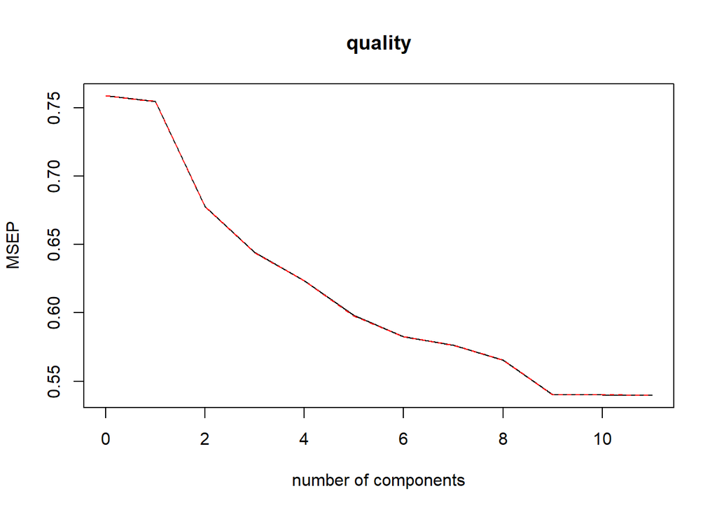

```r
validationplot(fit_pcr_cv, val.type="MSEP")
```

Here too the minimum MSEP is at the maximum number of PCs - 11. However, the MSEP schedule seems flat beginning at 9. The *pls* library has *selectNcomp()* function which chooses the optimal number of PCs - one based on a permutation test and one on the standard error of the CV residuals. We run it for both options to assist in choosing the optimal number of PCs:

```r
selectNcomp(fit_pcr_cv, "randomization")
```

```
## [1] 9
```

```r
selectNcomp(fit_pcr_cv, "onesigma")
```

```
## [1] 9
```

Both agree that the optimal number of PCs is 9.

## Q5

We now calculate the test MSE using both 9 PCs and the maximum (11) number of PCs:

```r
pcr_pred9 <- predict(fit_pcr_cv, wine_x_test, ncomp=9)
mean((pcr_pred9 - wine_y_test)^2)
```

```
## [1] 0.5374227
```

```r
pcr_pred11 <- predict(fit_pcr_cv, wine_x_test, ncomp=11)
mean((pcr_pred11 - wine_y_test)^2)
```

```
## [1] 0.5364479
```